# SF City Employee Compensation Part 3

Makena Haroldson

December 20, 2019

### **Review:**

Previously, in our first deliverable, we saw the hiearchary of city jobs of San Francsico and their organizations that they are within, as well as viewing the the job listings of them. In our secound deliverable, we saw that we can predict a job’s total benefit based on its salaries, other benefits, and its total compensation. Now, we are going to research if we can predict a job’s total compensation based on what organization they are in, the amount of employees in that organization, and the year. By doing so, we may be able to see if a job’s compensation is based on how impacted their organization is.

To start off, we will need to import the last two deliverables and any libraries we will need.

```r
include <- function(library_name){
  if( !(library_name %in% installed.packages()) )
    install.packages(library_name)
  library(library_name, character.only=TRUE)
}

suppressMessages(include("tidyverse"))
suppressMessages(include("knitr"))
suppressMessages(include("rvest"))
suppressMessages(include("tidyr"))

#links our first deliverable here
suppressMessages(purl("deliverable1.Rmd", output = "part1.r"))
```

[output not shown]

```
## [1] "part1.r"
```

```r
suppressMessages(source("part1.r"))

#links our second deliverable here
suppressMessages(purl("deliverable2.Rmd", output = "part2.r"))
```

[output not shown]

```
## [1] "part2.r"
```

```r
suppressWarnings(source("part2.r"))
```

[output not shown]

### **Part 1: Modeling Data cont.**

To be able to make the model to find if there is a correlation between compensation and the organization and their employement, we need to make a table that has the averages of pay and the number of employees for each organization by each year.

NOTE*: there are negative numbers that we will exlude when finding the averages of our financial columns.

```r
Organizations_info <- Employee_Compensation %>%  group_by(`Organization Group`,`Year`) %>% filter(`Salaries` > 0 & `Overtime`>=0 & `Other Salaries`>=0 & `Total Salary`>0 & `Retirement` >= 0 & `Health and Dental` >= 0& `Other Benefits`>=0 & `Total Benefits`>0 & `Total Compensation` > 0 & Year <= 2019) %>% summarize(Employee_total = n_distinct(`Employee Identifier`, na.rm=T), Salaries_ave = mean(`Salaries`), Overtime_ave = mean(`Overtime`), Other_Salaries_ave = mean(`Other Salaries`),Total_Salary_ave = mean(`Total Salary`), Retirement_ave = mean(`Retirement`), Health_ave = mean(`Health and Dental`), Other_Benefits_ave = mean(`Other Benefits`), Total_Benefits_ave = mean(`Total Benefits`), Total_Compensation_ave = mean(`Total Compensation`))

#View(Organizations_info)
Organizations_info
```

```
## # A tibble: 49 x 12
## # Groups:   Organization Group [7]
##    `Organization G~  Year Employee_total Salaries_ave Overtime_ave
##    <fct>            <dbl>          <int>        <dbl>        <dbl>
##  1 Community Health  2013           8424       63704.        1469.
##  2 Community Health  2014           8206       63698.        1453.
##  3 Community Health  2015           8614       65951.        1582.
##  4 Community Health  2016           8999       68804.        1775.
##  5 Community Health  2017           8813       57454.        1610.
##  6 Community Health  2018           7183       71386.        3208.
##  7 Community Health  2019           5054       77046.        4131.
##  8 Culture & Recre~  2013           3427       32839.         838.
##  9 Culture & Recre~  2014           3532       31724.         909.
## 10 Culture & Recre~  2015           3742       32721.        1019.
## # ... with 39 more rows, and 7 more variables: Other_Salaries_ave <dbl>,
## #   Total_Salary_ave <dbl>, Retirement_ave <dbl>, Health_ave <dbl>,
## #   Other_Benefits_ave <dbl>, Total_Benefits_ave <dbl>,
## #   Total_Compensation_ave <dbl>
```

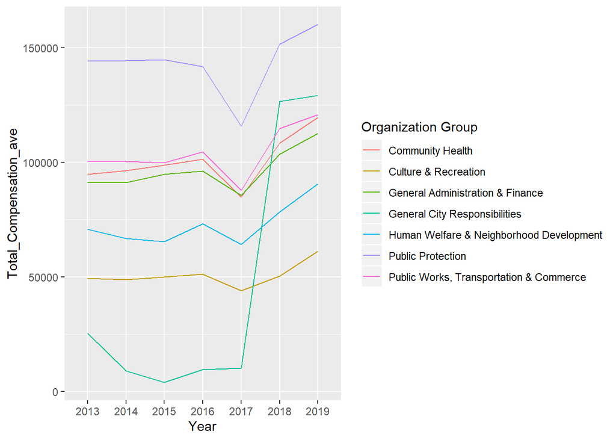

```r
Comp_plot <- ggplot(Organizations_info, aes(Year, Total_Compensation_ave, color = `Organization Group`)) + geom_line() + scale_x_discrete(name = "Year", breaks = seq(2013, 2019, by = 1), limits =seq(2013, 2019, by = 1))

Comp_plot
```

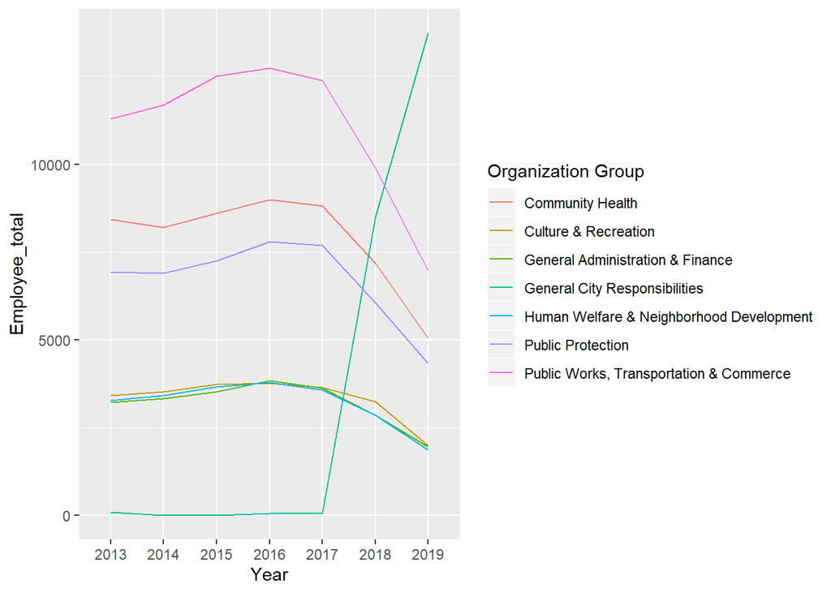

```r
Emp_plot <- ggplot(Organizations_info, aes(Year, Employee_total, color = `Organization Group`)) + geom_line() + scale_x_discrete(name = "Year", breaks = seq(2013, 2019, by = 1), limits =seq(2013, 2019, by = 1))

Emp_plot
```

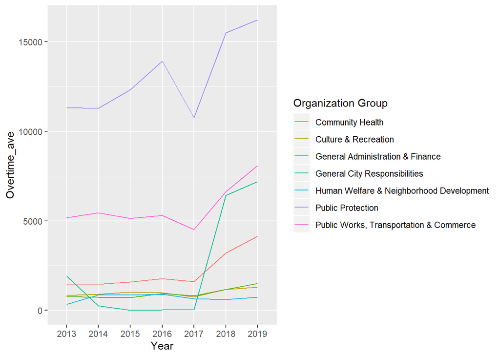

```r
Over_plot <- ggplot(Organizations_info, aes(Year, Overtime_ave, color = `Organization Group`)) + geom_line() + scale_x_discrete(name = "Year", breaks = seq(2013, 2019, by = 1), limits =seq(2013, 2019, by = 1))

Over_plot
```

Now we will be making our model to find if there is any correlation to Total Compensation.

```r
set.seed(763)

#random picking 70% of the data
sample2_selection <- Organizations_info$Total_Compensation_ave %>% createDataPartition(p = 0.7, list = FALSE)

train2 <-Organizations_info[sample2_selection,]
test2 <-Organizations_info[-sample2_selection,]

train2_model <- lm(data=train2, formula=Total_Compensation_ave ~ Year +`Organization Group` + Employee_total ,  na.action=na.exclude)

summary(train2_model)
```

```
##
## Call:
## lm(formula = Total_Compensation_ave ~ Year + `Organization Group` +
##     Employee_total, data = train2, na.action = na.exclude)
##
## Residuals:
##    Min     1Q Median     3Q    Max
## -37623  -7852    316   9890  38938
##
## Coefficients:
##                                                                   Estimate
## (Intercept)                                                  -10240071.398
## Year                                                              5104.232
## `Organization Group`Culture & Recreation                        -22383.593
## `Organization Group`General Administration & Finance             26291.325
## `Organization Group`General City Responsibilities               -25884.624
## `Organization Group`Human Welfare & Neighborhood Development      -569.276
## `Organization Group`Public Protection                            49988.007
## `Organization Group`Public Works, Transportation & Commerce      -7731.840
## Employee_total                                                       6.270
##                                                                 Std. Error
## (Intercept)                                                    3018832.610
## Year                                                              1495.673
## `Organization Group`Culture & Recreation                         13668.279
## `Organization Group`General Administration & Finance             12723.060
## `Organization Group`General City Responsibilities                15142.971
## `Organization Group`Human Welfare & Neighborhood Development     13202.394
## `Organization Group`Public Protection                            11022.468
## `Organization Group`Public Works, Transportation & Commerce      11799.983
## Employee_total                                                       1.708
##                                                              t value
## (Intercept)                                                   -3.392
## Year                                                           3.413
## `Organization Group`Culture & Recreation                      -1.638
## `Organization Group`General Administration & Finance           2.066
## `Organization Group`General City Responsibilities             -1.709
## `Organization Group`Human Welfare & Neighborhood Development  -0.043
## `Organization Group`Public Protection                          4.535
## `Organization Group`Public Works, Transportation & Commerce   -0.655
## Employee_total                                                 3.672
##                                                               Pr(>|t|)
## (Intercept)                                                    0.00208 **
## Year                                                           0.00198 **
## `Organization Group`Culture & Recreation                       0.11269
## `Organization Group`General Administration & Finance           0.04815 *
## `Organization Group`General City Responsibilities              0.09845 .
## `Organization Group`Human Welfare & Neighborhood Development   0.96591
## `Organization Group`Public Protection                        0.0000987 ***
## `Organization Group`Public Works, Transportation & Commerce    0.51766
## Employee_total                                                 0.00101 **
## ---
## Signif. codes:  0 '***' 0.001 '**' 0.01 '*' 0.05 '.' 0.1 ' ' 1
##
## Residual standard error: 17030 on 28 degrees of freedom
## Multiple R-squared:  0.8618, Adjusted R-squared:  0.8223
## F-statistic: 21.83 on 8 and 28 DF,  p-value: 0.0000000004167
```

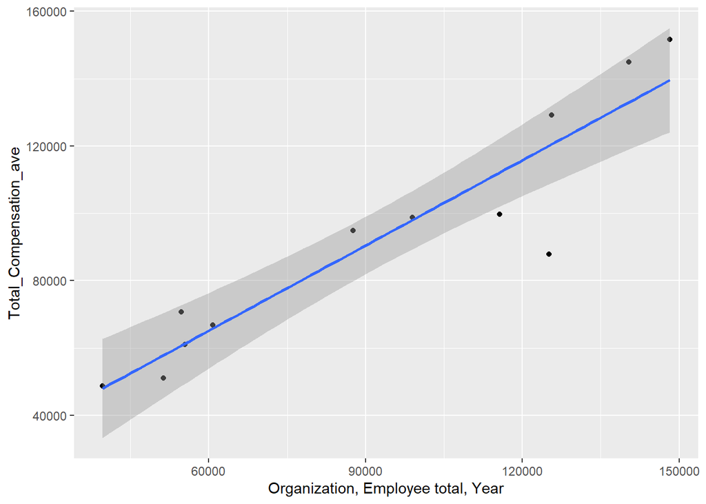

```r
predictions2 <- train2_model %>% predict(test2)

ggplot(data = test2, aes(x=predictions2, y = Total_Compensation_ave)) + geom_point() + scale_x_continuous(name = "Organization, Employee total, Year") + geom_smooth(method = "lm")
```

```r
#r^2: how strong the correlation is
#(root it, 1 being stronger correlation)
R2 <- caret::R2(predictions2, test2$Total_Compensation_ave)
R2
```

```
## [1] 0.8700758
```

```r
#MAE: Mean absolute error - tells how big an error we can expect the smaller the number, the more accurate
MAE <-MAE(predictions2, test2$Total_Compensation_ave)
MAE
```

```
## [1] 9102.1
```

```r
#RMSE: Root Mean Square Error - measure of how spread out the prediction errors(r^2) are
RMSE <-RMSE(predictions2, test2$Total_Compensation_ave)
RMSE
```

```
## [1] 13389.43
```

**Model Results**

Our p-value for our predicting values are all pretty small, most being less than .5, except for Human Welfare & Neighborhood Development and Public Works, Transportation & Commerce Organization Groups. This means these predicters have signifigance between each other a job’s compensation is dependent on their organization group, the amount of employees in them, and the year. Respectively, as 1 year goes by, one’s compensation increases by $5104 and when a new person gets a job, a person’s compensation would go up by $6.27. For organization groups, if a person joins the Public Protection (ex. legal courts and police), their compensation will be increase about $49988. However, if someone works in Public Works, Transportation, and Commerce(ex. airport and MTA) their compensation will be $7731 less than others, as well as General City Responsibilities (ex. Court-Judge and Traffic Survey Technician) which will decrease by $25884.

Most of our variables are somewhat significant with an $r^2$ of 82%. This means that using the year, an organization’s employement total, the distinguishing the organization, itself, we can estimate about 82% of how much a job’s compensation will be. On the other hand, our mean absolute error is large so our model is not fully accurate.

### **Part 2: Operationalization**

From the newest model we did find that there is a slight positive correlation between a job’s total compensation and their organization’s employement total. By this discovery, we could increase the amount of jobs in these groups, however, there are major flaws to this proposal. Just because we increase the jobs does not mean more people will be able to work for them. These jobs have skill requirements especially attorneys and accountents that are needed, but of course, if someone has the skills and intelligence for them, why not work for a private company where they could have a much better income. To solve this complication, we can increase the pay of these jobs, but this will lead us to the problem of what would be the source of this money.

We saw how drasticlly greater Public Protection’s overtime average was to all the other groups so one idea could be to decrease the amount of hours these employees can work overtime and give this money to the previously mentioned organizations. That means less workers working at a time, which could be either good or bad. If we put this policy into place, we definitly need to watch crime rates and fire statistics. Will crime rates increase, if so was it because there were less cops on duty or because those on duty did not have back up. Are fires and emergencies still quickly handled or instead is there an increase in fatalities because the situations were handled slowly. These are the social implications that may happen and so after collecting new data, we need to reanalyze it and see the changes that have occured.